# Analisis Hubungan Budget Profit terhadap Profit

Kevin Kristi F

2026-04-17

```r
#Import data Excel ke R
data_coffe <- read_xlsx("D:/Kuliah/Tugas SIM B/DATA COFFE.xlsx")
print(data_coffe)
```

```
## # A tibble: 4,248 × 20
##    `Area Code` Date                Market  `Market Size` Product  `Product Line`
##          <dbl> <dttm>              <chr>   <chr>         <chr>    <chr>
##  1         719 2012-01-01 00:00:00 Central Major Market  Amaretto Beans
##  2         970 2012-01-01 00:00:00 Central Major Market  Colombi… Beans
##  3         970 2012-01-01 00:00:00 Central Major Market  Decaf I… Beans
##  4         303 2012-01-01 00:00:00 Central Major Market  Green T… Leaves
##  5         303 2012-01-01 00:00:00 Central Major Market  Caffe M… Beans
##  6         720 2012-01-01 00:00:00 Central Major Market  Decaf E… Beans
##  7         970 2012-01-01 00:00:00 Central Major Market  Chamomi… Leaves
##  8         719 2012-01-01 00:00:00 Central Major Market  Lemon    Leaves
##  9         970 2012-01-01 00:00:00 Central Major Market  Mint     Leaves
## 10         719 2012-01-01 00:00:00 Central Major Market  Darjeel… Leaves
## # ℹ 4,238 more rows
## # ℹ 14 more variables: `Product Type` <chr>, State <chr>, Type <chr>,
## #   `Budget COGS` <dbl>, `Budget Margin` <dbl>, `Budget Profit` <dbl>,
## #   `Budget Sales` <dbl>, COGS <dbl>, Inventory <dbl>, Margin <dbl>,
## #   Marketing <dbl>, Profit <dbl>, Sales <dbl>, `Total Expenses` <dbl>
```

```r
cat("Di sini saya mengimport data dari format .xlsx ke RMarkdown dengan R Studio")
```

```
## Di sini saya mengimport data dari format .xlsx ke RMarkdown dengan R Studio
```

#INTERPRETASI Saya akan menganalisis Budget Profit dan Profit di 2 State yaitu di Iowa dan Colorado.

```r
#Cek tipe data
str(data_coffe)
```

```
## tibble [4,248 × 20] (S3: tbl_df/tbl/data.frame)
##  $ Area Code     : num [1:4248] 719 970 970 303 303 720 970 719 970 719 ...
##  $ Date          : POSIXct[1:4248], format: "2012-01-01" "2012-01-01" ...
##  $ Market        : chr [1:4248] "Central" "Central" "Central" "Central" ...
##  $ Market Size   : chr [1:4248] "Major Market" "Major Market" "Major Market" "Major Market" ...
##  $ Product       : chr [1:4248] "Amaretto" "Colombian" "Decaf Irish Cream" "Green Tea" ...
##  $ Product Line  : chr [1:4248] "Beans" "Beans" "Beans" "Leaves" ...
##  $ Product Type  : chr [1:4248] "Coffee" "Coffee" "Coffee" "Tea" ...
##  $ State         : chr [1:4248] "Colorado" "Colorado" "Colorado" "Colorado" ...
##  $ Type          : chr [1:4248] "Regular" "Regular" "Decaf" "Regular" ...
##  $ Budget COGS   : num [1:4248] 90 80 100 30 60 80 140 50 50 40 ...
##  $ Budget Margin : num [1:4248] 130 110 140 50 90 130 160 80 70 70 ...
##  $ Budget Profit : num [1:4248] 100 80 110 30 70 80 110 20 40 20 ...
##  $ Budget Sales  : num [1:4248] 220 190 240 80 150 210 300 130 120 110 ...
##  $ COGS          : num [1:4248] 89 83 95 44 54 72 170 63 60 58 ...
##  $ Inventory     : num [1:4248] 777 623 821 623 456 ...
##  $ Margin        : num [1:4248] 130 107 139 56 80 108 171 87 80 72 ...
##  $ Marketing     : num [1:4248] 24 27 26 14 15 23 47 57 19 22 ...
##  $ Profit        : num [1:4248] 94 68 101 30 54 53 99 0 33 17 ...
##  $ Sales         : num [1:4248] 219 190 234 100 134 180 341 150 140 130 ...
##  $ Total Expenses: num [1:4248] 36 39 38 26 26 55 72 87 47 55 ...
```

#INTERPRETASI Di sini saya mengecek struktur data, apakah data tersebut char, num, dll.

```r
#Filter data yang mau dianalisis
data_analisis <- data_coffe %>%
  filter(Market == "Central",
         State %in% c("Iowa", "Colorado"))

print(data_analisis)
```

```
## # A tibble: 480 × 20
##    `Area Code` Date                Market  `Market Size` Product  `Product Line`
##          <dbl> <dttm>              <chr>   <chr>         <chr>    <chr>
##  1         719 2012-01-01 00:00:00 Central Major Market  Amaretto Beans
##  2         970 2012-01-01 00:00:00 Central Major Market  Colombi… Beans
##  3         970 2012-01-01 00:00:00 Central Major Market  Decaf I… Beans
##  4         303 2012-01-01 00:00:00 Central Major Market  Green T… Leaves
##  5         303 2012-01-01 00:00:00 Central Major Market  Caffe M… Beans
##  6         720 2012-01-01 00:00:00 Central Major Market  Decaf E… Beans
##  7         970 2012-01-01 00:00:00 Central Major Market  Chamomi… Leaves
##  8         719 2012-01-01 00:00:00 Central Major Market  Lemon    Leaves
##  9         970 2012-01-01 00:00:00 Central Major Market  Mint     Leaves
## 10         719 2012-01-01 00:00:00 Central Major Market  Darjeel… Leaves
## # ℹ 470 more rows
## # ℹ 14 more variables: `Product Type` <chr>, State <chr>, Type <chr>,
## #   `Budget COGS` <dbl>, `Budget Margin` <dbl>, `Budget Profit` <dbl>,
## #   `Budget Sales` <dbl>, COGS <dbl>, Inventory <dbl>, Margin <dbl>,
## #   Marketing <dbl>, Profit <dbl>, Sales <dbl>, `Total Expenses` <dbl>
```

#INTERPRETASI Saya memfilter data menggunakan package ‘dplyr’ untuk mengambil variabel dan kolom yang saya pilih, yaitu Market yang berada di Central, State yang berada di Iowa dan Colorado

```r
#Uji normalitas Budget Profit & Profit di Iowa

#1 Budget Profit
shapiro.test(data_analisis$`Budget Profit`[data_analisis$State == "Iowa"])
```

```
##
##  Shapiro-Wilk normality test
##
## data:  data_analisis$`Budget Profit`[data_analisis$State == "Iowa"]
## W = 0.84228, p-value = 4.668e-14
```

```r
cat("Budget Profit di Iowa tidak berdistribusi normal.")
```

```
## Budget Profit di Iowa tidak berdistribusi normal.
```

```r
#2 Profit
shapiro.test(data_analisis$Profit[data_analisis$State == "Iowa"])
```

```
##
##  Shapiro-Wilk normality test
##
## data:  data_analisis$Profit[data_analisis$State == "Iowa"]
## W = 0.83035, p-value = 1.284e-14
```

```r
cat("Profit di Iowa tidak berdistribusi normal.")
```

```
## Profit di Iowa tidak berdistribusi normal.
```

#INTERPRETASI Dari hasil uji normalitas pada Budget Profit dan Profit di Iowa dapat disimpulkan bahwa kedua data di atas tidak berdistribusi normal

```r
#Uji normalitas Budget Profit & Profit di Colorado

#1 Budget Profit
shapiro.test(data_analisis$`Budget Profit`[data_analisis$State == "Colorado"])
```

```
##
##  Shapiro-Wilk normality test
##
## data:  data_analisis$`Budget Profit`[data_analisis$State == "Colorado"]
## W = 0.93595, p-value = 2.724e-09
```

```r
cat("Budget Profit di Colorado tidak berdistribusi normal.")
```

```
## Budget Profit di Colorado tidak berdistribusi normal.
```

```r
#2 Profit
shapiro.test(data_analisis$Profit[data_analisis$State == "Colorado"])
```

```
##
##  Shapiro-Wilk normality test
##
## data:  data_analisis$Profit[data_analisis$State == "Colorado"]
## W = 0.95305, p-value = 1.622e-07
```

```r
cat("Profit di Colorado tidak berdistribusi normal.")
```

```
## Profit di Colorado tidak berdistribusi normal.
```

#INTERPRETASI Dari hasil uji normalitas pada Budget Profit dan Profit di Colorado dapat disimpulkan bahwa kedua data di atas tidak berdistribusi normal.

```r
#Uji normalitas Budget Profit & Profit(Iowa + Colorado)

#1 Budget Profit
shapiro.test(data_analisis$`Budget Profit`)
```

```
##
##  Shapiro-Wilk normality test
##
## data:  data_analisis$`Budget Profit`
## W = 0.89349, p-value < 2.2e-16
```

```r
cat("Budget Profit tidak berdistribusi normal.")
```

```
## Budget Profit tidak berdistribusi normal.
```

```r
#2 Profit
shapiro.test(data_analisis$Profit)
```

```
##
##  Shapiro-Wilk normality test
##
## data:  data_analisis$Profit
## W = 0.86979, p-value < 2.2e-16
```

```r
cat("Profit tidak berdistribusi normal.")
```

```
## Profit tidak berdistribusi normal.
```

#INTERPRETASI Dari hasil uji normalitas pada Budget Profit dan Profit di kedua wilayah tersebut dapat disimpulkan bahwa kedua data di atas tidak berdistribusi normal.

```r
#Rata-rata per Budget Profit dan Profit

#Iowa
#1 Rata-rata Budget Profit di Iowa
cat("Rata-rata Budget Profit di Iowa =")
```

```
## Rata-rata Budget Profit di Iowa =
```

```r
mean(data_analisis$`Budget Profit`[data_analisis$State == "Iowa"])
```

```
## [1] 84.90741
```

```r
#2 Rata-rata Profit di Iowa
cat("Rata-rata Profit di Iowa =")
```

```
## Rata-rata Profit di Iowa =
```

```r
mean(data_analisis$Profit[data_analisis$State == "Iowa"])
```

```
## [1] 102.8333
```

```r
#Colorado
#1 Rata-rata Budget Profit di Colorado
cat("Rata-rata Budget Profit di Colorado =")
```

```
## Rata-rata Budget Profit di Colorado =
```

```r
mean(data_analisis$`Budget Profit`[data_analisis$State == "Colorado"])
```

```
## [1] 66.74242
```

```r
#2 Rata-rata Profit di Colorado
cat("Rata-rata Profit di Colorado =")
```

```
## Rata-rata Profit di Colorado =
```

```r
mean(data_analisis$Profit[data_analisis$State == "Colorado"])
```

```
## [1] 67.20833
```

```r
#Rata-rata Budget Profit di Iowa + Colorado
cat("Rata-rata Budget Profit di Iowa + Colorado =")
```

```
## Rata-rata Budget Profit di Iowa + Colorado =
```

```r
mean(data_analisis$`Budget Profit`)
```

```
## [1] 74.91667
```

```r
#Rata-rata Profit di Iowa + Colorado
cat("Rata-rata Profit di Iowa + Colorado,")
```

```
## Rata-rata Profit di Iowa + Colorado,
```

```r
mean(data_analisis$Profit)
```

```
## [1] 83.23958
```

#INTERPRETASI Dari hasil rata-rata di atas Profit > Budget Profit. Dapat disimpulkan bahwa perusahaan yang menjual coffe di State Iowa dan Colorado mampu mengelola anggaran dengan efektif sehingga keuntungan tercapai.

```r
#Uji Hipotesis Budget Profit dan Profit di wilayah masing-masing

#1 Iowa

uji_Iowa <- wilcox.test(
  data_analisis$`Budget Profit`[data_analisis$State == "Iowa"],
  data_analisis$Profit[data_analisis$State == "Iowa"],
  paired = TRUE
)
print(uji_Iowa)
```

```
##
##  Wilcoxon signed rank test with continuity correction
##
## data:  data_analisis$`Budget Profit`[data_analisis$State == "Iowa"] and data_analisis$Profit[data_analisis$State == "Iowa"]
## V = 9279, p-value = 0.0107
## alternative hypothesis: true location shift is not equal to 0
```

```r
cat("H0: Tidak terdapat perbedaan yang signifikan \n")
```

```
## H0: Tidak terdapat perbedaan yang signifikan
```

```r
cat("H1: Terdapat perbedaan yang signifikan \n")
```

```
## H1: Terdapat perbedaan yang signifikan
```

```r
cat("\nKESIMPULAN:\n")
```

```
##
## KESIMPULAN:
```

```r
cat("1. Nilai p-value =", uji_Iowa$p.value, "\n")
```

```
## 1. Nilai p-value = 0.01069634
```

```r
cat("2. Karena p-value < 0.05, maka tolak H0.\n")
```

```
## 2. Karena p-value < 0.05, maka tolak H0.
```

```r
cat("Terdapat perbedaan signifikan antara Budget Profit dan Profit di Iowa.")
```

```
## Terdapat perbedaan signifikan antara Budget Profit dan Profit di Iowa.
```

```r
#2 Colorado
uji_Colorado <- wilcox.test(
  data_analisis$`Budget Profit`[data_analisis$State == "Colorado"],
  data_analisis$Profit[data_analisis$State == "Colorado"],
  paired = TRUE
)
print(uji_Colorado)
```

```
##
##  Wilcoxon signed rank test with continuity correction
##
## data:  data_analisis$`Budget Profit`[data_analisis$State == "Colorado"] and data_analisis$Profit[data_analisis$State == "Colorado"]
## V = 17251, p-value = 0.4985
## alternative hypothesis: true location shift is not equal to 0
```

```r
cat("H0: Tidak terdapat perbedaan yang signifikan \n")
```

```
## H0: Tidak terdapat perbedaan yang signifikan
```

```r
cat("H1: Terdapat perbedaan yang signifikan \n")
```

```
## H1: Terdapat perbedaan yang signifikan
```

```r
cat("\nKESIMPULAN:\n")
```

```
##
## KESIMPULAN:
```

```r
cat("1. Nilai p-value =", uji_Colorado$p.value, "\n")
```

```
## 1. Nilai p-value = 0.4985128
```

```r
cat("2. Karena p-value > 0.05, maka gagal tolak H0.\n")
```

```
## 2. Karena p-value > 0.05, maka gagal tolak H0.
```

```r
cat("Tidak ada perbedaan signifikan antara Budget Profit dan Profit di Colorado. \n")
```

```
## Tidak ada perbedaan signifikan antara Budget Profit dan Profit di Colorado.
```

#INTERPRETASI

1. Hasil Uji

Dari hasil dari uji Wilcox.test di atas dapat disimpulkan bahwa Iowa lebih banyak mendapatkan keuntungan daripada Colorado dikarenakan adanya perbedaan yang signifikan di Iowa terhadap Budget Profit dan Profit sementara di Corolado tidak terdapat perbedaan yang signifikan terhadap Budget Profit dan Profit.

```r
#Ringkasan rata-rata per State dan selisih
data_analisis %>%
  mutate(Selisih = Profit - `Budget Profit`) %>%
  group_by(State) %>%
  summarise(
    rata_profit = mean(Profit),
    rata_budget = mean(`Budget Profit`),
    rata_selisih = mean(Selisih)
  )
```

```
## # A tibble: 2 × 4
##   State    rata_profit rata_budget rata_selisih
##   <chr>          <dbl>       <dbl>        <dbl>
## 1 Colorado        67.2        66.7        0.466
## 2 Iowa           103.         84.9       17.9
```

```r
cat("Berdasarkat analisis rata-rata di atas diperoleh bahwa selisih rata rata di Colorado jauh di bawah Iowa, dengan ini dapat disimpulkan bahwa Colorado kurang efektif dan efisien dalam mengelola anggaran dibandingkan dengan Iowa, sedangkan Iowa jauh di atas Colorado.")
```

```
## Berdasarkat analisis rata-rata di atas diperoleh bahwa selisih rata rata di Colorado jauh di bawah Iowa, dengan ini dapat disimpulkan bahwa Colorado kurang efektif dan efisien dalam mengelola anggaran dibandingkan dengan Iowa, sedangkan Iowa jauh di atas Colorado.
```

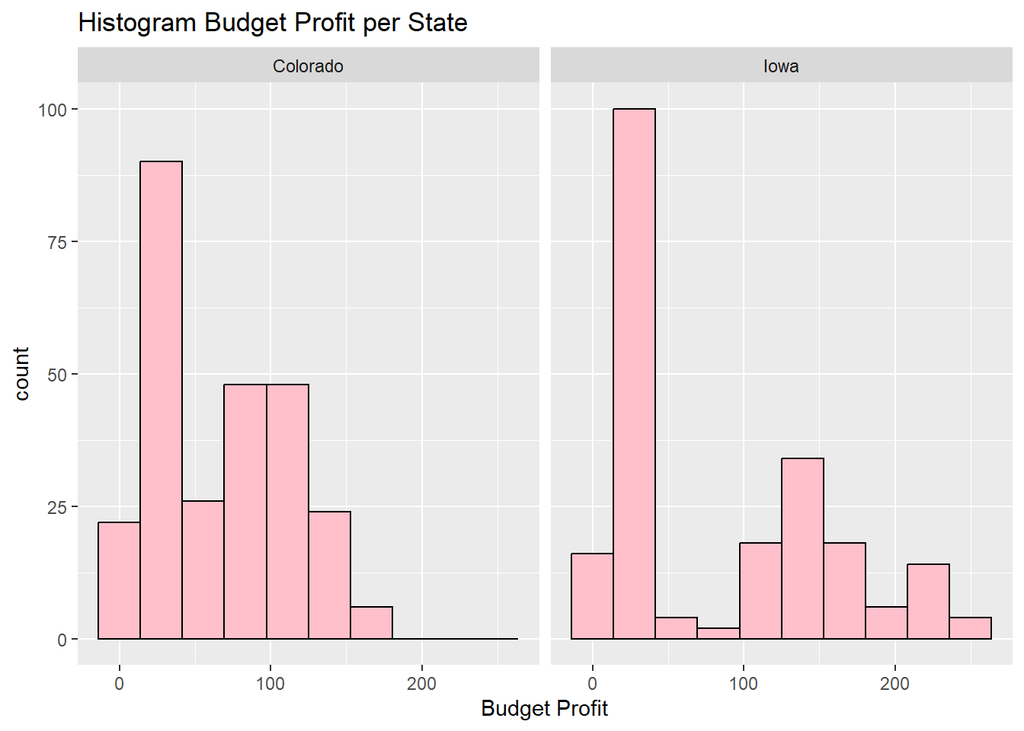

```r
#Visualisasi data

#Histogram Budget Profit per State
ggplot(data_analisis, aes(x = `Budget Profit`)) +
  geom_histogram(bins = 10, fill="pink", color="black") +
  facet_wrap(~State) +
  ggtitle("Histogram Budget Profit per State")
```

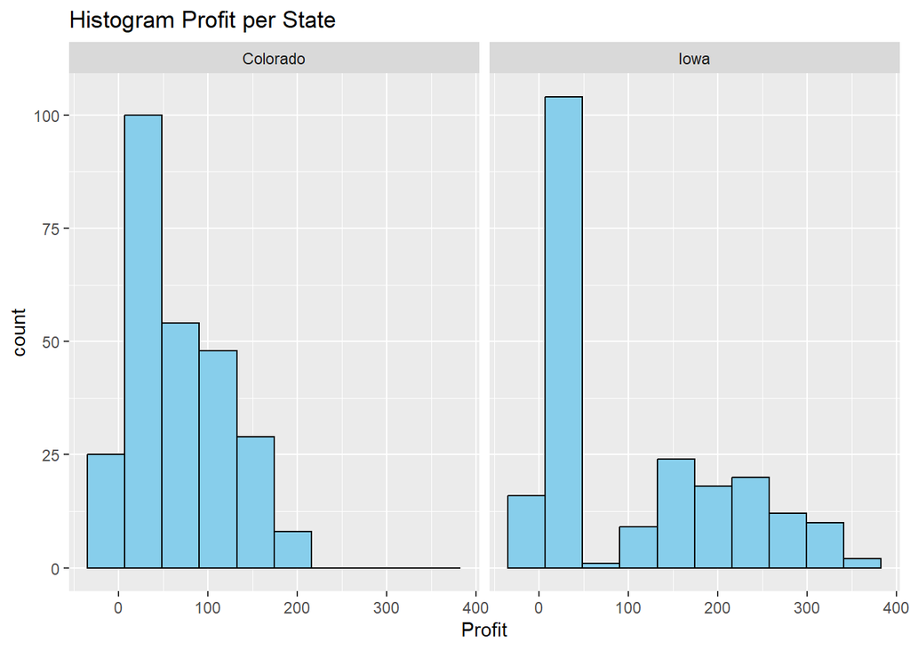

```r
#Histogram Profit per State
ggplot(data_analisis, aes(x = Profit)) +
  geom_histogram(bins = 10, fill="skyblue", color="black") +
  facet_wrap(~State) +
  ggtitle("Histogram Profit per State")
```

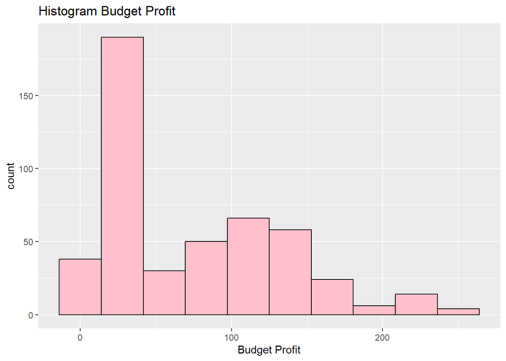

```r
#Histogram Budget Profit di Iowa + Colorado
ggplot(data_analisis, aes(x = `Budget Profit`)) +
  geom_histogram(bins = 10, fill="pink", color="black") +
  ggtitle("Histogram Budget Profit")
```